# MEDBS datacall Report

## 8.1 Check the numbers by age in landing and discard from Catch table

### 8.1.1 GSA 18

#### 8.1.1.1 ANE

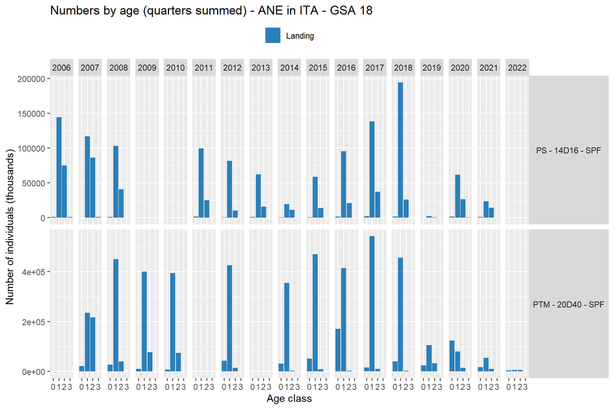

#### DPS

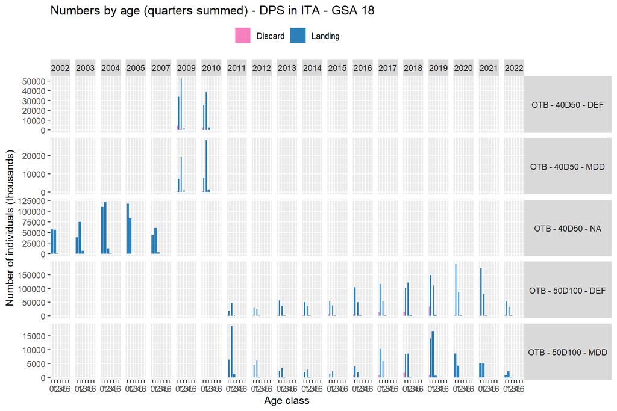

#### HKE

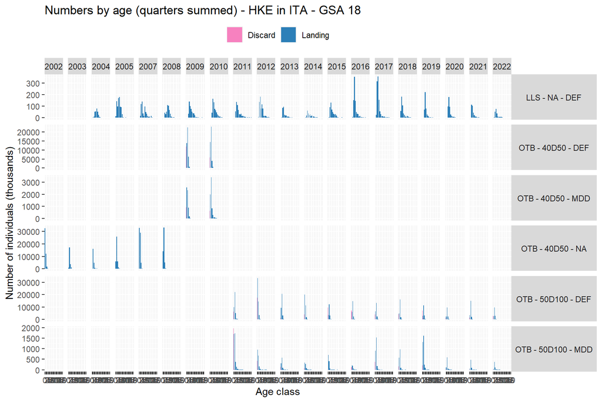

#### MUT

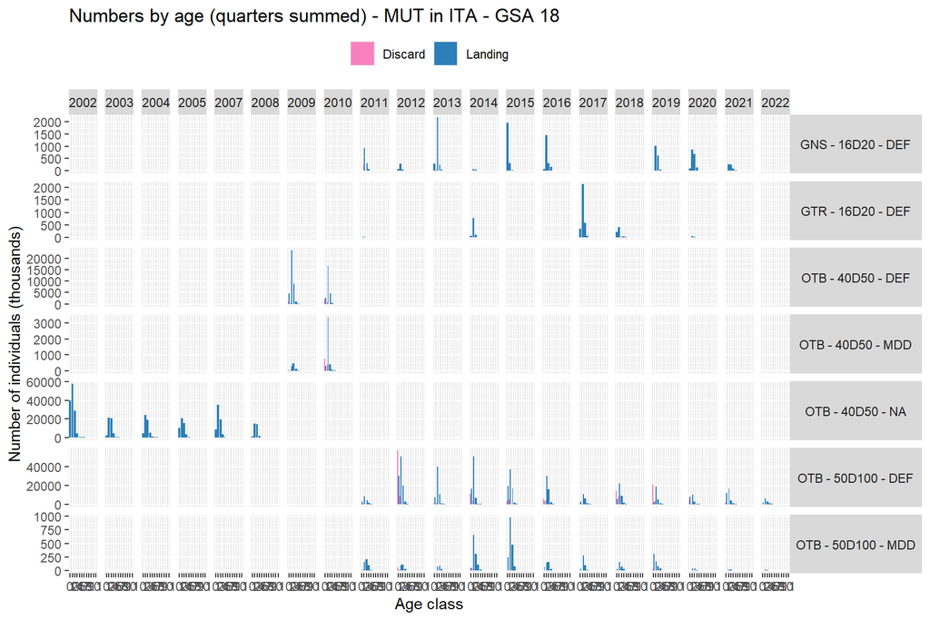

#### NEP

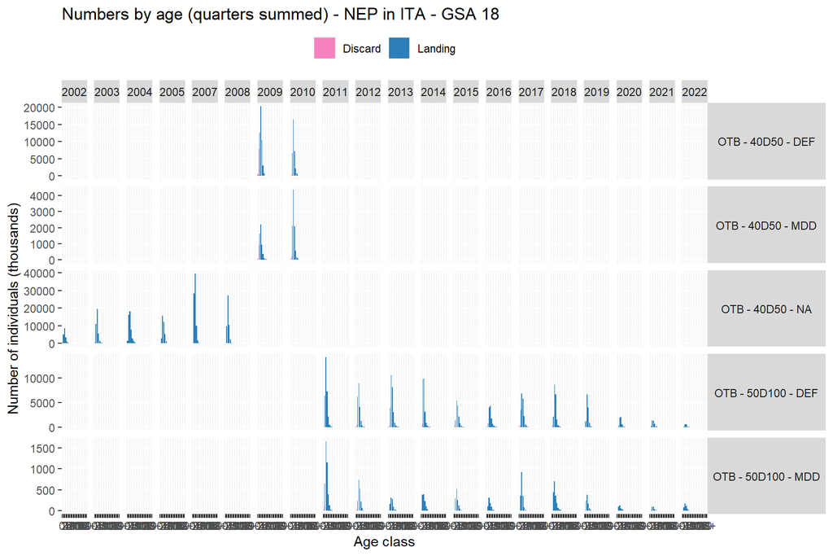